# 2.2 웹 크롤링 기초

### 책대로~!

```python
songs = soup.select('table>tbody>tr')
print(len(songs))
print(songs[0])
```

```
100
<tr class="lst50" data-song-no="34845949" id="lst50">
<td><div class="wrap t_right"><input class="input_check" name="input_check" title="봄여름가을겨울 (Still Life) 곡 선택" type="checkbox" value="34845949"/></div></td>
<td><div class="wrap t_center"><span class="rank">1</span><span class="none">위</span></div></td>
<!-- 차트순위 추가 -->
<td><div class="wrap">
<span class="rank_wrap" title="순위 동일">
<span class="bullet_icons rank_static"><span class="none">순위 동일</span></span>
<span class="none">0</span>
</span>
</div></td>
<td><div class="wrap">
<a class="image_typeAll" href="javascript:melon.link.goAlbumDetail('10908834');" title="봄여름가을겨울 (Still Life)">
<img alt="봄여름가을겨울 (Still Life) - 페이지 이동" height="60" onerror="WEBPOCIMG.defaultAlbumImg(this);" src="https://cdnimg.melon.co.kr/cm2/album/images/109/08/834/10908834_20220404174407_500.jpg/melon/resize/120/quality/80/optimize" width="60"/>
<span class="bg_album_frame"></span>
</a>
</div></td>
<td><div class="wrap">
<a class="btn button_icons type03 song_info" href="javascript:melon.link.goSongDetail('34845949');" title="봄여름가을겨울 (Still Life) 곡정보"><span class="none">곡정보</span></a>
</div></td>
<td><div class="wrap">
<div class="wrap_song_info">
<div class="ellipsis rank01"><span>
<a href="javascript:melon.play.playSong('1000002721',34845949);" title="봄여름가을겨울 (Still Life) 재생">봄여름가을겨울 (Still Life)</a>
</span></div><br/>
<div class="ellipsis rank02">
<a href="javascript:melon.link.goArtistDetail('198094');" title="BIGBANG (빅뱅) - 페이지 이동">BIGBANG (빅뱅)</a><span class="checkEllipsis" style="display: none;"><a href="javascript:melon.link.goArtistDetail('198094');" title="BIGBANG (빅뱅) - 페이지 이동">BIGBANG (빅뱅)</a></span>
</div>
</div>
</div></td>
<td><div class="wrap">
<div class="wrap_song_info">
<div class="ellipsis rank03">
<a href="javascript:melon.link.goAlbumDetail('10908834');" title="봄여름가을겨울 (Still Life) - 페이지 이동">봄여름가을겨울 (Still Life)</a>
</div>
</div>
</div></td>
<td><div class="wrap">
<button class="button_etc like" data-song-menuid="1000002721" data-song-no="34845949" title="봄여름가을겨울 (Still Life) 좋아요" type="button"><span class="odd_span">좋아요</span>
<span class="cnt">
<span class="none">총건수</span>
210,253</span></button>
</div></td>
<td><div class="wrap t_center">
<button class="button_icons play" onclick="melon.play.playSong('1000002721',34845949);" title="듣기" type="button"><span class="none">듣기</span></button>
</div></td>
<td><div class="wrap t_center">
<button class="button_icons scrap" onclick="melon.play.addPlayList('34845949');" title="담기" type="button"><span class="none">담기</span></button>
</div></td>
<td><div class="wrap t_center">
<button class="button_icons download" onclick="melon.buy.goBuyProduct('frm', '34845949', '3C0001', '','0', '1000002721');" title="다운로드" type="button"><span class="none">다운로드</span></button>
</div></td>
<td><div class="wrap t_center">
<button class="button_icons video" onclick="melon.link.goMvDetail('1000002721', '34845949','song');" title="뮤직비디오" type="button"><span class="none">뮤직비디오</span></button>
</div></td>
</tr>
```

[figure not shown]

위의 출력결과가 그림의 한블럭을 구성하는데 작성된 html구조

#### 제목찾기

```python
song = songs[0]
print(song.select('a'))
print(len(song.select('a')))
```

```
[<a class="image_typeAll" href="javascript:melon.link.goAlbumDetail('10908834');" title="봄여름가을겨울 (Still Life)">
<img alt="봄여름가을겨울 (Still Life) - 페이지 이동" height="60" onerror="WEBPOCIMG.defaultAlbumImg(this);" src="https://cdnimg.melon.co.kr/cm2/album/images/109/08/834/10908834_20220404174407_500.jpg/melon/resize/120/quality/80/optimize" width="60"/>
<span class="bg_album_frame"></span>
</a>, <a class="btn button_icons type03 song_info" href="javascript:melon.link.goSongDetail('34845949');" title="봄여름가을겨울 (Still Life) 곡정보"><span class="none">곡정보</span></a>, <a href="javascript:melon.play.playSong('1000002721',34845949);" title="봄여름가을겨울 (Still Life) 재생">봄여름가을겨울 (Still Life)</a>, <a …
6
```

```python
print(song.select('span>a'))
print(len(song.select('span>a')))
```

```
[<a href="javascript:melon.play.playSong('1000002721',34845949);" title="봄여름가을겨울 (Still Life) 재생">봄여름가을겨울 (Still Life)</a>, <a href="javascript:melon.link.goArtistDetail('198094');" title="BIGBANG (빅뱅) - 페이지 이동">BIGBANG (빅뱅)</a>]
2
```

```python
print(song.select('div.ellipsis.rank01>span>a'))
print(len(song.select('div.ellipsis.rank01>span>a')))
```

```
[<a href="javascript:melon.play.playSong('1000002721',34845949);" title="봄여름가을겨울 (Still Life) 재생">봄여름가을겨울 (Still Life)</a>]
1
```

```python
title1=song.select('div.ellipsis.rank01>span>a')[0].text
title1
```

```
'봄여름가을겨울 (Still Life)'
```

#### 가수찾기

```python
print(song.select('div.ellipsis.rank02>a'))
print(len(song.select('div.ellipsis.rank02>a')))
```

```
[<a href="javascript:melon.link.goArtistDetail('198094');" title="BIGBANG (빅뱅) - 페이지 이동">BIGBANG (빅뱅)</a>]
1
```

```python
singer1= song.select('div.ellipsis.rank02>a')[0].text
singer1
```

```
'BIGBANG (빅뱅)'
```

```python
# 책대로 하면 또 중복 가수 문제지롱 ^.^;;
songs[22].select('div.ellipsis.rank02>a')
```

```
[<a href="javascript:melon.link.goArtistDetail('2137482');" title="(여자)아이들 - 페이지 이동">(여자)아이들</a>]
```

```python
## 책코드 정리
from selenium import webdriver
driver = webdriver.Edge('./msedgedriver.exe')
url = 'http://www.melon.com/chart/index.htm'
driver.get(url)

from bs4 import BeautifulSoup
html = driver.page_source
soup = BeautifulSoup(html, 'html.parser')

songs=soup.select('tbody>tr')
for song in songs:
    title = song.select('div.ellipsis.rank01>span>a')[0].text
    singer = song.select('div.ellipsis.rank02>a')[0].text
    print(title,singer,sep='::')
```

```
봄여름가을겨울 (Still Life)::BIGBANG (빅뱅)
TOMBOY::(여자)아이들
LOVE DIVE::IVE (아이브)
Feel My Rhythm::Red Velvet (레드벨벳)
사랑인가 봐::멜로망스
GANADARA (Feat. 아이유)::박재범
사랑은 늘 도망가::임영웅
취중고백::김민석 (멜로망스)
INVU::태연 (TAEYEON)
듣고 싶을까::MSG워너비(M.O.M)
ELEVEN::IVE (아이브)
다정히 내 이름을 부르면::경서예지
RUN2U::STAYC(스테이씨)
SMILEY (Feat. BIBI)::YENA (최예나)
언제나 사랑해::케이시 (Kassy)
신호등::이무진
STAY::The Kid LAROI
존재만으로::원슈타인
이제 나만 믿어요::임영웅
회전목마 (Feat. Zion.T, 원슈타인) (Prod. Slom)::sokodomo
버퍼링 (Glitch Mode)::NCT DREAM
드라마::아이유
MY BAG::(여자)아이들
LOVE me::BE'O (비오)
Step Back::GOT the beat
strawberry moon::아이유
다시 사랑한다면 (김필 Ver.)::임영웅
Next Level::aespa
Weekend::태연 (TAEYEON)
리무진 (Feat. MINO) (Prod. GRAY)::BE'O (비오)
그대라는 사치::임영웅
사랑인걸::한동근
Real Love::오마이걸 (OH MY GIRL)
내가 아니라도::주호
너를 생각해::주시크 (Joosiq)
어제처럼::폴킴
별빛 같은 나의 사랑아::임영웅
잊었니::임영웅
abcdefu::GAYLE
너, 너 (N번째 연애 X 휘인 (Whee In))::휘인 (Whee In)
```

[output cut: 45 more lines]

```
롤린 (Rollin')::브레이브걸스
Can't Control Myself::태연 (TAEYEON)
언덕나무::이승윤
아주, 천천히::비비 (BIBI)
Stronger (What Doesn't Kill You)::Kelly Clarkson
북극성 (Never Goodbye)::NCT DREAM
계단말고 엘리베이터::임영웅
That's Hilarious::Charlie Puth
Christmas Tree::V
우연히 봄::로꼬
With::김태리
꽃 (With 김민석 of 멜로망스)::박봄 (Park Bom)
흔들리는 꽃들 속에서 네 샴푸향이 느껴진거야::장범준
Arcade::NCT DREAM
우리가 헤어져야 했던 이유::비비 (BIBI)
```

### selenium으로 크롤링

BeautifulSoup : select -> selenium : find_element_by_css_selector

```python
driver = webdriver.Edge('./msedgedriver.exe')
url = 'http://www.melon.com/chart/index.htm'
driver.get(url)

songs=driver.find_elements_by_css_selector('tabel>tbody>tr')
for song in songs:
    title=song.find_element_by_css_selector('div.ellipsis.rank01>span>a')[0].text
    singer=song.find_element_by_css_selector('div.ellipsis.rank02>span>a')[0].text
    print(title,singer,sep='::')
```

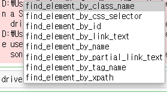

**selenium.find_element...**

selenium은 다양한 find_element 메소드들을 제공하며 입력요소의 차이존재  
https://pythonblog.co.kr/coding/22/ 이 사이트가 잘 정리해 논 것을 가져옴

| 단일 element | 복수 elements | 설명 |
| --- | --- | --- |
| find_element_by_id | - | 태그의 id값으로 추출 |
| find_element_by_name | find_elements_by_name | 태그의 name값으로 추출 |
| find_element_by_xpath | find_elements_by_xpath | 태그의 경로로 추출 |
| find_element_by_link_text | find_elements_by_link_text | a태그 텍스트값으로 추출 |
| find_element_by_partial_link_text | find_elements_by_partial_link_text | a태그의 자식 텍스트값으로 추출 *(..?)* |
| find_element_by_tag_name | find_elements_by_tag_name | 태그 이름으로 추출 |
| find_element_by_class_name | find_elements_by_class_name | 태그의 클래스명으로 추출 |
| find_element_by_css_selector | find_elements_by_css_selector | css선택자로 추출 (beautifulsoup의 select메소드와 동일) |

- 단일element와 복수 elements는 추출 결과가 다름  
  단일은 첫번째 element만 추출  
  복수는 입력요소에 해당하는 모든 elements를 가져와 list로 저장